```python
import numpy as np
import pandas as pd
import seaborn as sbn
```

# Introduction

```python
water_quality = None

water_quality = pd.read_csv("WaterQualityData.csv")

water_quality
```

|  | Site_Id | Unit_Id | Read_Date | Salinity (ppt) | Dissolved Oxygen (mg/L) | pH (standard units) | Secchi Depth (m) | Water Depth (m) | Water Temp (?C) | Air Temp-Celsius | Air Temp (?F) | Time (24:00) | Field_Tech | DateVerified | WhoVerified | AirTemp (C) | Year |
| --- | --- | --- | --- | --- | --- | --- | --- | --- | --- | --- | --- | --- | --- | --- | --- | --- | --- |
| 0 | Bay | NaN | 1/3/1994 | 1.3 | 11.7 | 7.3 | 0.40 | 0.40 | 5.9 | 8.0 | 46.40 | 11:00 | NaN | NaN | NaN | 8.000000 | 1994 |
| 1 | Bay | NaN | 1/31/1994 | 1.5 | 12.0 | 7.4 | 0.20 | 0.35 | 3.0 | 2.6 | 36.68 | 11:30 | NaN | NaN | NaN | 2.600000 | 1994 |
| 2 | Bay | NaN | 2/7/1994 | 1.0 | 10.5 | 7.2 | 0.25 | 0.60 | 5.9 | 7.6 | 45.68 | 9:45 | NaN | NaN | NaN | 7.600000 | 1994 |
| 3 | Bay | NaN | 2/23/1994 | 1.0 | 10.1 | 7.4 | 0.35 | 0.50 | 10.0 | 2.7 | 36.86 | NaN | NaN | NaN | NaN | 2.700000 | 1994 |
| 4 | Bay | NaN | 2/28/1994 | 1.0 | 12.6 | 7.2 | 0.20 | 0.40 | 1.6 | 0.0 | 32.00 | 10:30 | NaN | NaN | NaN | 0.000000 | 1994 |
| ... | ... | ... | ... | ... | ... | ... | ... | ... | ... | ... | ... | ... | ... | ... | ... | ... | ... |
| 2366 | Bay | NaN | 10/11/2018 | 1.9 | 5.0 | 7.0 | 4.00 | 1.20 | 25.0 | NaN | 78.00 | 09:30 | Sue Poe | 11/13/2019 | Christine Folks | 25.555556 | 2018 |
| 2367 | Bay | NaN | 10/24/2018 | 0.0 | 9.0 | 7.0 | 0.30 | 0.60 | 18.0 | NaN | 58.00 | 09:30 | Sue Poe | 11/13/2019 | Christine Folks | 14.444444 | 2018 |
| 2368 | Bay | NaN | 10/28/2018 | 0.9 | 2.9 | 7.0 | 0.40 | 0.90 | 13.0 | NaN | 49.00 | 09:20 | Sue Poe | 11/13/2019 | Christine Folks | 9.444444 | 2018 |
| 2369 | Bay | NaN | 11/7/2018 | 1.7 | NaN | 7.0 | 0.45 | 0.90 | 20.0 | NaN | 65.00 | 09:45 | Sue Poe | 11/13/2019 | Christine Folks | 18.333333 | 2018 |
| 2370 | Bay | NaN | 12/11/2018 | 0.1 | NaN | 7.0 | 0.10 | 0.10 | 10.0 | NaN | 42.00 | 09:40 | Sue Poe | 11/13/2019 | Christine Folks | 5.555556 | 2018 |

2371 rows × 17 columns

# Preprocessing

This data was found all in one dataset, so no merging was performed between frames. To prepare this data, I began by reviewing the columns and removing those that were of little value to my analysis. Also, I decided to index the frame by the date the data was recorded as this makes the data more natural to read.

```python
water_quality = water_quality.drop(['Unit_Id', 'Air Temp-Celsius', 'Time (24:00)', 'Field_Tech', 'DateVerified', 'WhoVerified', 'AirTemp (C)','Year'], axis=1)

water_quality = water_quality.set_index('Read_Date')

water_quality
```

| Read_Date | Site_Id | Salinity (ppt) | Dissolved Oxygen (mg/L) | pH (standard units) | Secchi Depth (m) | Water Depth (m) | Water Temp (?C) | Air Temp (?F) |
| --- | --- | --- | --- | --- | --- | --- | --- | --- |
| 1/3/1994 | Bay | 1.3 | 11.7 | 7.3 | 0.40 | 0.40 | 5.9 | 46.40 |
| 1/31/1994 | Bay | 1.5 | 12.0 | 7.4 | 0.20 | 0.35 | 3.0 | 36.68 |
| 2/7/1994 | Bay | 1.0 | 10.5 | 7.2 | 0.25 | 0.60 | 5.9 | 45.68 |
| 2/23/1994 | Bay | 1.0 | 10.1 | 7.4 | 0.35 | 0.50 | 10.0 | 36.86 |
| 2/28/1994 | Bay | 1.0 | 12.6 | 7.2 | 0.20 | 0.40 | 1.6 | 32.00 |
| ... | ... | ... | ... | ... | ... | ... | ... | ... |
| 10/11/2018 | Bay | 1.9 | 5.0 | 7.0 | 4.00 | 1.20 | 25.0 | 78.00 |
| 10/24/2018 | Bay | 0.0 | 9.0 | 7.0 | 0.30 | 0.60 | 18.0 | 58.00 |
| 10/28/2018 | Bay | 0.9 | 2.9 | 7.0 | 0.40 | 0.90 | 13.0 | 49.00 |
| 11/7/2018 | Bay | 1.7 | NaN | 7.0 | 0.45 | 0.90 | 20.0 | 65.00 |
| 12/11/2018 | Bay | 0.1 | NaN | 7.0 | 0.10 | 0.10 | 10.0 | 42.00 |

2371 rows × 8 columns

Next, I converted the water temperature from Celsius to Fahrenheit to both match the units of the air temperature as well as provide the reader with more natural data. Then, I renamed some of the columns for clarification. These changes helped synchronize the units of the data and organize it into a more legible form.

```python
water_quality['Water Temp (?C)'] = water_quality['Water Temp (?C)'] * 9/5 + 32

water_quality = water_quality.rename(columns={'Water Temp (?C)': 'Water Temp (F)', 'Air Temp (?F)': 'Air Temp (F)'})

water_quality
```

| Read_Date | Site_Id | Salinity (ppt) | Dissolved Oxygen (mg/L) | pH (standard units) | Secchi Depth (m) | Water Depth (m) | Water Temp (F) | Air Temp (F) |
| --- | --- | --- | --- | --- | --- | --- | --- | --- |
| 1/3/1994 | Bay | 1.3 | 11.7 | 7.3 | 0.40 | 0.40 | 42.62 | 46.40 |
| 1/31/1994 | Bay | 1.5 | 12.0 | 7.4 | 0.20 | 0.35 | 37.40 | 36.68 |
| 2/7/1994 | Bay | 1.0 | 10.5 | 7.2 | 0.25 | 0.60 | 42.62 | 45.68 |
| 2/23/1994 | Bay | 1.0 | 10.1 | 7.4 | 0.35 | 0.50 | 50.00 | 36.86 |
| 2/28/1994 | Bay | 1.0 | 12.6 | 7.2 | 0.20 | 0.40 | 34.88 | 32.00 |
| ... | ... | ... | ... | ... | ... | ... | ... | ... |
| 10/11/2018 | Bay | 1.9 | 5.0 | 7.0 | 4.00 | 1.20 | 77.00 | 78.00 |
| 10/24/2018 | Bay | 0.0 | 9.0 | 7.0 | 0.30 | 0.60 | 64.40 | 58.00 |
| 10/28/2018 | Bay | 0.9 | 2.9 | 7.0 | 0.40 | 0.90 | 55.40 | 49.00 |
| 11/7/2018 | Bay | 1.7 | NaN | 7.0 | 0.45 | 0.90 | 68.00 | 65.00 |
| 12/11/2018 | Bay | 0.1 | NaN | 7.0 | 0.10 | 0.10 | 50.00 | 42.00 |

2371 rows × 8 columns

Then, I wanted to remove any rows that contained missing values. However, I first wanted to ensure that there would still be a sufficient distribution of data recorded between the five different pools. Once I confirmed that there would be enough data to represent each pool in the refuge, I decided to simply remove the rows that contained missing values rather than fill the missing values with a representative value.

```python
water_quality = water_quality.dropna()

print(water_quality["Site_Id"].value_counts())

water_quality
```

```
Site_Id
Bay    661
D      195
B      164
A      156
C      100
Name: count, dtype: int64
```

| Read_Date | Site_Id | Salinity (ppt) | Dissolved Oxygen (mg/L) | pH (standard units) | Secchi Depth (m) | Water Depth (m) | Water Temp (F) | Air Temp (F) |
| --- | --- | --- | --- | --- | --- | --- | --- | --- |
| 1/3/1994 | Bay | 1.3 | 11.7 | 7.3 | 0.40 | 0.40 | 42.62 | 46.40 |
| 1/31/1994 | Bay | 1.5 | 12.0 | 7.4 | 0.20 | 0.35 | 37.40 | 36.68 |
| 2/7/1994 | Bay | 1.0 | 10.5 | 7.2 | 0.25 | 0.60 | 42.62 | 45.68 |
| 2/23/1994 | Bay | 1.0 | 10.1 | 7.4 | 0.35 | 0.50 | 50.00 | 36.86 |
| 2/28/1994 | Bay | 1.0 | 12.6 | 7.2 | 0.20 | 0.40 | 34.88 | 32.00 |
| ... | ... | ... | ... | ... | ... | ... | ... | ... |
| 10/11/2018 | D | 0.0 | 6.0 | 6.5 | 0.70 | 1.20 | 78.80 | 78.00 |
| 11/7/2018 | D | 0.0 | 6.9 | 6.5 | 0.90 | 1.30 | 68.00 | 65.00 |
| 10/11/2018 | Bay | 1.9 | 5.0 | 7.0 | 4.00 | 1.20 | 77.00 | 78.00 |
| 10/24/2018 | Bay | 0.0 | 9.0 | 7.0 | 0.30 | 0.60 | 64.40 | 58.00 |
| 10/28/2018 | Bay | 0.9 | 2.9 | 7.0 | 0.40 | 0.90 | 55.40 | 49.00 |

1276 rows × 8 columns

The last step of preprocessing the data involved identifying any outlier values in the quantitative columns. This will help me discover any inconsistencies that may have occurred during the measuring of this data. I decided to group the data by the five different pools of water as the results of one pool should not impact the results of another. I did not the want to calculate outliers that created misconceptions of the actual data as the five pools are located in five different areas of the refuge. Note that if a pool does not appear in the list of outliers, then that pool does not have any outliers for that measurement.

```python
by_pool = water_quality.groupby("Site_Id")

def is_outlier(x):
    Q25, Q75 = x.quantile([.25,.75])
    I = Q75 - Q25
    return (x < Q25 - 1.5*I) |  (x > Q75 + 1.5*I)

outliers_salt = by_pool["Salinity (ppt)"].transform(is_outlier)
print("Salinity Outliers")
print(water_quality.loc[outliers_salt,"Site_Id"].value_counts())
print("")

outliers_DO = by_pool["Dissolved Oxygen (mg/L)"].transform(is_outlier)
print("Dissolved Oxygen Outliers")
print(water_quality.loc[outliers_DO,"Site_Id"].value_counts())
print("")

outliers_pH = by_pool["pH (standard units)"].transform(is_outlier)
print("pH Outliers")
print(water_quality.loc[outliers_pH,"Site_Id"].value_counts())
print("")

outliers_turb = by_pool["Secchi Depth (m)"].transform(is_outlier)
print("Secchi Depth Outliers")
print(water_quality.loc[outliers_turb,"Site_Id"].value_counts())
print("")

outliers_depth = by_pool["Water Depth (m)"].transform(is_outlier)
print("Water Depth Outliers")
print(water_quality.loc[outliers_depth,"Site_Id"].value_counts())
print("")

outliers_watemp = by_pool["Water Temp (F)"].transform(is_outlier)
print("Water Temp Outliers")
print(water_quality.loc[outliers_watemp,"Site_Id"].value_counts())
print("")

outliers_airtemp = by_pool["Air Temp (F)"].transform(is_outlier)
print("Air Temp Outliers")
print("None of the pools have outliers for air temperature")
print(water_quality.loc[outliers_airtemp,"Site_Id"].value_counts())
```

```
Salinity Outliers
Site_Id
B      39
A      38
D      18
C       6
Bay     3
Name: count, dtype: int64

Dissolved Oxygen Outliers
Site_Id
Bay    2
C      2
Name: count, dtype: int64

pH Outliers
Site_Id
D      71
A      25
B       2
Bay     2
C       1
Name: count, dtype: int64

Secchi Depth Outliers
Site_Id
Bay    22
A       5
B       3
D       3
Name: count, dtype: int64

Water Depth Outliers
Site_Id
Bay    16
D       7
B       4
A       2
C       2
Name: count, dtype: int64

Water Temp Outliers
Site_Id
Bay    2
A      1
D      1
Name: count, dtype: int64

Air Temp Outliers
None of the pools have outliers for air temperature
Series([], Name: count, dtype: int64)
```

# Summary Data Analysis

Now that the data is well prepared for analysis, I can explore the standard summary statistics for each quantitative column. Again, I grouped the data by the five pools of water to make the outputs more natural. Simultaneously, I am going to plot the data, so I can gain a better understanding of how it is actually behaving. Additionally, organizing the outputs by each quantitative column allows me to analyze how each individual measurement varies between the pools.

```
Water Temp
         count       mean        std    min   25%   50%   75%    max
Site_Id
A        156.0  66.926923  15.469368  37.40  53.6  69.8  78.8  140.0
B        164.0  65.093659  14.799033  35.60  53.6  68.0  78.8   94.1
Bay      661.0  63.268015  14.446407  34.34  51.8  63.5  76.1  165.2
C        100.0  64.895000  15.905595  33.80  50.0  66.2  78.8  109.4
D        195.0  64.742462  15.634240  32.00  52.7  66.2  78.8  129.2

Air Temp
         count       mean        std   min    25%   50%    75%   max
Site_Id
A        156.0  63.247179  15.805530  26.0  50.75  66.0  77.00  88.0
B        164.0  61.449146  15.902048  23.0  48.15  63.0  75.00  89.0
Bay      661.0  62.236436  14.725684  25.0  50.00  62.6  75.20  92.3
C        100.0  61.693000  16.103549  11.5  48.00  62.5  74.25  88.0
D        195.0  61.971077  15.512472  12.0  48.00  63.0  75.00  88.0

Water Depth
         count      mean       std   min  25%   50%  75%  max
Site_Id
A        156.0  0.816026  0.569040  0.10  0.6  0.80  1.0  7.0
B        164.0  0.329634  0.399357  0.01  0.2  0.30  0.4  4.5
Bay      661.0  0.698570  0.547189  0.03  0.5  0.66  0.8  7.5
C        100.0  0.451700  0.220491  0.10  0.3  0.45  0.6  1.5
D        195.0  1.355026  0.273612  0.13  1.2  1.40  1.5  2.1
```

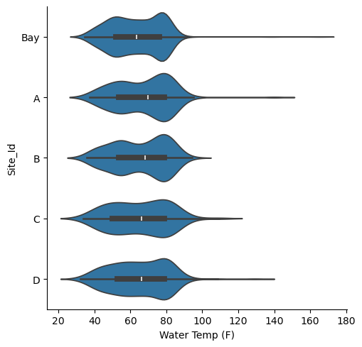

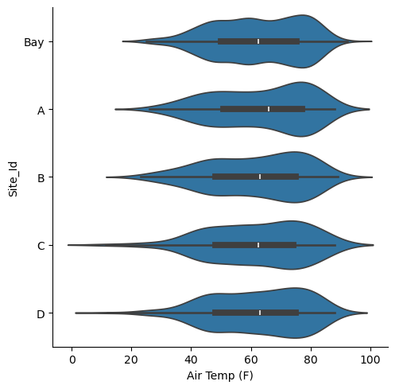

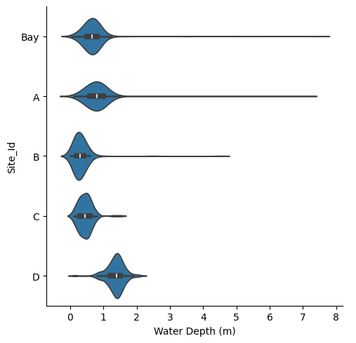

```python
print("Water Temp")
print(by_pool["Water Temp (F)"].describe())
print("")
print("Air Temp")
print(by_pool["Air Temp (F)"].describe())
print("")
print("Water Depth")
print(by_pool["Water Depth (m)"].describe())
sbn.catplot(data=water_quality, x="Water Temp (F)", y="Site_Id", kind="violin")
sbn.catplot(data=water_quality, x="Air Temp (F)", y="Site_Id", kind="violin")
sbn.catplot(data=water_quality, x="Water Depth (m)", y="Site_Id", kind="violin")
```

Analyzing the data by columns allows me to see that the data for both water temp and air temp are very similar for all five pools. This is a very standard measurement to record, and it is apparent that the temperatures would be similar as all five pools are in the same refuge in Virginia. From the graphs, I can see that the water temperature would commonly retain the extreme air temperatures, but this is a typical quality of water because of its high heat capacity. Additionally, the water depth column does not provide any surprising conclusions as it is simply the result of natural variations in the bodies of water, and the graphs depict normal distributions in this data.

```
Salinity
         count      mean       std  min  25%  50%    75%  max
Site_Id
A        156.0  0.347692  0.760398  0.0  0.0  0.0  0.000  3.0
B        164.0  0.432927  0.872421  0.0  0.0  0.0  0.275  4.0
Bay      661.0  1.489713  1.593030  0.0  0.0  1.0  2.900  9.0
C        100.0  0.501100  0.846263  0.0  0.0  0.0  1.000  3.5
D        195.0  0.091487  0.318060  0.0  0.0  0.0  0.000  2.0

Dissolved Oxygen
         count      mean       std  min    25%  50%    75%   max
Site_Id
A        156.0  5.383974  2.002458  0.0  3.900  5.0  6.800  10.0
B        164.0  5.401585  2.163687  0.0  3.800  5.3  7.025  10.0
Bay      661.0  7.716430  2.461330  0.1  6.000  7.8  9.500  15.1
C        100.0  5.563000  1.782273  1.9  4.375  5.3  6.425   9.9
D        195.0  6.466410  2.098069  2.0  5.000  6.1  8.100  10.3
```

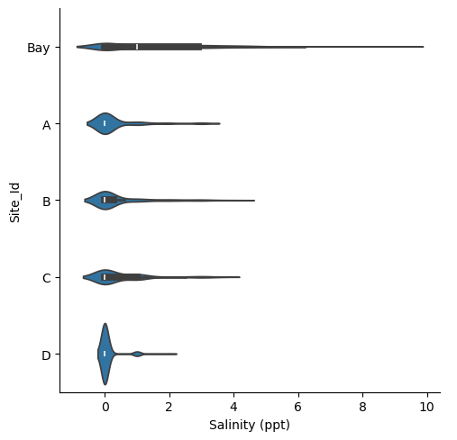

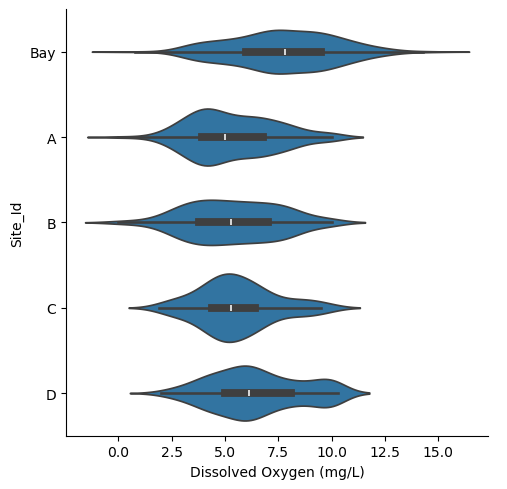

```python
print("Salinity")
print(by_pool["Salinity (ppt)"].describe())
print("")
print("Dissolved Oxygen")
print(by_pool["Dissolved Oxygen (mg/L)"].describe())
sbn.catplot(data=water_quality, x="Salinity (ppt)", y="Site_Id", kind="violin")
sbn.catplot(data=water_quality, x="Dissolved Oxygen (mg/L)", y="Site_Id", kind="violin")
```

The rest of the columns do display some exciting results. The salinity of the bay pool is much higher and has a wider distribution than the other four pools because they are intended to be freshwater while the bay is the only pool that is directly connected to the Atlantic Ocean. The other four pools are secluded, so this verifies why the measurements are clustered towards the lower salinity levels in the salinity graph. Additionally, given the size of the bay, it averages more dissolved oxygen because it has a larger surface area to collect the oxygen from the air compared to the smaller pools. The graph of the bay's dissolved oxygen levels resembles a normal distribtion, which supports the consistency in the recorded measurements. However, freshwater is better than salt water at absorbing dissolved oxygen, so this helps explain why the dissolved oxygen average for the bay is not too much higher than the other pools. Furthermore, the D-pool is a freshwater fishing pond, so the high dissolved oxygen levels relative to the other three pools can likely be attributed to the decrease in fish that absorb the oxygen.

```
Secchi Depth
         count      mean       std   min     25%    50%   75%  max
Site_Id
A        156.0  0.607051  0.452928  0.00  0.4375  0.575  0.70  5.5
B        164.0  0.306890  0.367354  0.00  0.2000  0.250  0.40  4.0
Bay      661.0  0.407322  0.469375  0.03  0.2500  0.350  0.45  7.4
C        100.0  0.422600  0.176416  0.10  0.3000  0.400  0.55  0.9
D        195.0  0.889128  0.341444  0.10  0.7000  0.900  1.10  2.0

pH
         count      mean       std  min  25%  50%    75%  max
Site_Id
A        156.0  6.935897  0.856772  0.3  6.5  7.0  7.000  9.2
B        164.0  7.312195  0.728372  6.0  7.0  7.0  7.825  9.7
Bay      661.0  7.377080  0.767799  5.7  7.0  7.0  8.000  9.9
C        100.0  7.300000  0.654742  6.0  7.0  7.0  7.900  9.5
D        195.0  6.696410  0.733188  5.0  6.5  6.5  6.500  9.3
```

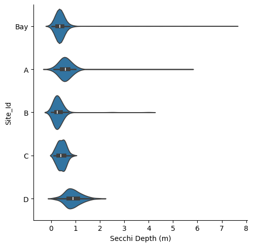

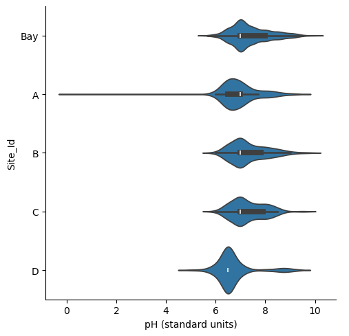

```python
print("Secchi Depth")
print(by_pool["Secchi Depth (m)"].describe())
print("")
print("pH")
print(by_pool["pH (standard units)"].describe())
sbn.catplot(data=water_quality, x="Secchi Depth (m)", y="Site_Id", kind="violin")
sbn.catplot(data=water_quality, x="pH (standard units)", y="Site_Id", kind="violin")
```

Next, I explored the correlations between salinity and pH, dissolved oxygen and turbidity, dissolved oxygen and water temperature, and pH and water depth. Again, I grouped the data by each pool to prevent any false correlations, such as those that appear through the Simpson's paradox. Additionally, I decided to calculate the Spearman coefficient as I calculated a large number of outliers for some columns, so I wanted to lessen their impact on the correlation. Graphing the scatterplots between the respective columns also allowed me to visually understand the behavior of the data.

```
Correlation between Salinity and pH

Site_Id
A      0.462851
B      0.356092
Bay    0.308925
C      0.411849
D     -0.062838
dtype: float64
```

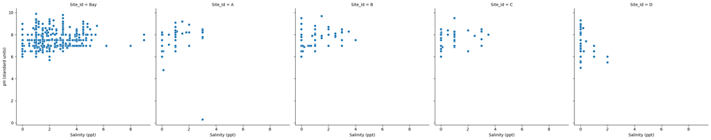

```python
correlation_by_pool = by_pool.apply(lambda x: x['Salinity (ppt)'].corr(x['pH (standard units)'], method='spearman'))
print("Correlation between Salinity and pH")
print("")
print(correlation_by_pool)
sbn.relplot( data=water_quality, x="Salinity (ppt)", y="pH (standard units)", kind = "scatter", col = "Site_Id")
```

While there does not appear to be anything more than a moderate positive correlation between salinity and pH in most of the pools, the slight negative correlation in pool D grabs attention. However, once the graph is further examined, it can be seen that most of the salinity values for pool D appear to be very close or equal to 0, so the few points that have higher salinity levels seem to pull the correlation a little negative. Nonetheless, from the other four pools it appears that as salinity increases, pH tends to increase.

```
Correlation between Dissolved Oxygen and Secchi Depth

Site_Id
A      0.228879
B      0.172859
Bay   -0.402239
C      0.117189
D      0.533812
dtype: float64
```

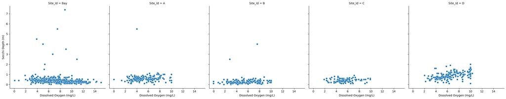

```python
correlation_by_pool = by_pool.apply(lambda x: x['Dissolved Oxygen (mg/L)'].corr(x['Secchi Depth (m)'], method='spearman'))
print("Correlation between Dissolved Oxygen and Secchi Depth")
print("")
print(correlation_by_pool)
sbn.relplot( data=water_quality, x="Dissolved Oxygen (mg/L)", y="Secchi Depth (m)", kind = "scatter", col = "Site_Id")
```

The moderately positive correlation in pool D and the moderately negative correlation in the bay definitely standout in this analysis. While there appears to be no significant correlation in the other three pools, the bay and pool D depict correlations in opposing directions. It appears that a tendency cannot be stated about this relationship because of how much the correlation values vary.

```
Correlation between Dissolved Oxygen and Water Temp

Site_Id
A     -0.591336
B     -0.567870
Bay   -0.487778
C     -0.580896
D     -0.792397
dtype: float64
```

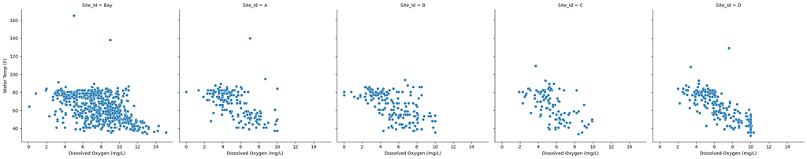

```python
correlation_by_pool = by_pool.apply(lambda x: x['Dissolved Oxygen (mg/L)'].corr(x['Water Temp (F)'], method='spearman'))
print("Correlation between Dissolved Oxygen and Water Temp")
print("")
print(correlation_by_pool)
sbn.relplot( data=water_quality, x="Dissolved Oxygen (mg/L)", y="Water Temp (F)", kind = "scatter", col = "Site_Id")
```

All five pools depict a moderate to strong negative correlation between their dissolved oxygen levels and water temperature, so it appears that as dissolved oxygen levels increase, the water temperature tends to decrease. There is nothing that stands out about this relationship as all five pools follow the same trend.

```
Correlation between pH and Water Depth

Site_Id
A      0.000110
B     -0.012994
Bay    0.093002
C     -0.183627
D     -0.275356
dtype: float64
```

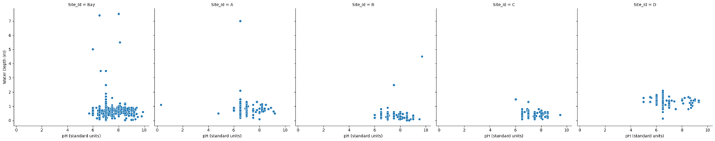

```python
correlation_by_pool = by_pool.apply(lambda x: x['pH (standard units)'].corr(x['Water Depth (m)'], method='spearman'))
print("Correlation between pH and Water Depth")
print("")
print(correlation_by_pool)
sbn.relplot( data=water_quality, x="pH (standard units)", y="Water Depth (m)", kind = "scatter", col = "Site_Id")
```

There appears to be very little association between pH and water depth as all five pools of water depict weak Spearmen coefficients and their graphs display the same weak relationship. It might be eye-opening that pool A and the Bay have positive values, but they are so close to zero that this concern is essentially negligible. Therefore, no relationship appears to be shown.

# Discussion

Two questions that I would want to explore in future projects about my water quality data include:

1. Can the pH, salinity, turbidity, and dissolved oxygen levels of a sample of water predict which pool of water an aquatic organism was retrieved from in the Back Bay National Wildlife Refuge?
2. Can pH, salinity, turbidity, and water temperature measurements be used to predict the dissolved oxygen level of a specific pool of water in the Back Bay National Wildlife Refuge?